# Exercise #3

Fortgeschrittene Statistische Software für NF - SS 2024

Qiaomu_Lu(12265424)

2024-05-27

# Exercise 1

## 1d)

Strengths:

1. Very hard to lose files with git.
2. Great for collaboration.

Weaknesses:

1. Not good for storing data.
2. Man need to use it explicitly, instead in the background.

# Exercise 2

Link to my repository: https://github.com/QiaomuLu/exeRcise-sheet-3

# Exercise 3

## 3b)

The datatype of variable “anzahl” in these data sets are not numeric, but character.

I used function “transform()”. It changed the datatype of “anzahl” successfully, however there were “4 oder weniger” as values in the raw dataframes, which turned into NA after I using “transform()”.

```r
vornamen_2022 <- read.csv("data/open_data_portal_2022.csv")
vornamen_2023 <- read.csv("data/vornamen-muenchen-2023.csv")

vornamen_2022_3b <- setNames(vornamen_2022, tolower(colnames(vornamen_2022)))
vornamen_2023_3b <- setNames(vornamen_2023, tolower(colnames(vornamen_2023)))

typeof(vornamen_2022_3b$anzahl)
```

```
## [1] "character"
```

```r
typeof(vornamen_2023_3b$anzahl)
```

```
## [1] "character"
```

```r
vornamen_2022_3b <- transform(vornamen_2022_3b, anzahl = as.numeric(anzahl))
vornamen_2023_3b <- transform(vornamen_2023_3b, anzahl = as.numeric(anzahl))
```

## 3c)

Not counting the babies with the first names, which have less than 5 owners, the babies born in Munich in 2022 was 9899 and in 2023 was 9277. Year 2022 had the bigger baby-boom.

```r
sum(vornamen_2022_3b$anzahl, na.rm = TRUE)
```

```
## [1] 9899
```

```r
sum(vornamen_2023_3b$anzahl, na.rm = TRUE)
```

```
## [1] 9277
```

## 3d)

```r
vornamen_2022_3d <- vornamen_2022_3b %>% mutate(year = 2022)
vornamen_2023_3d <- vornamen_2023_3b %>% mutate(year = 2023)
```

## 3e)

```r
vornamen_combined_3e <- bind_rows(vornamen_2022_3d, vornamen_2023_3d)
```

## 3f)

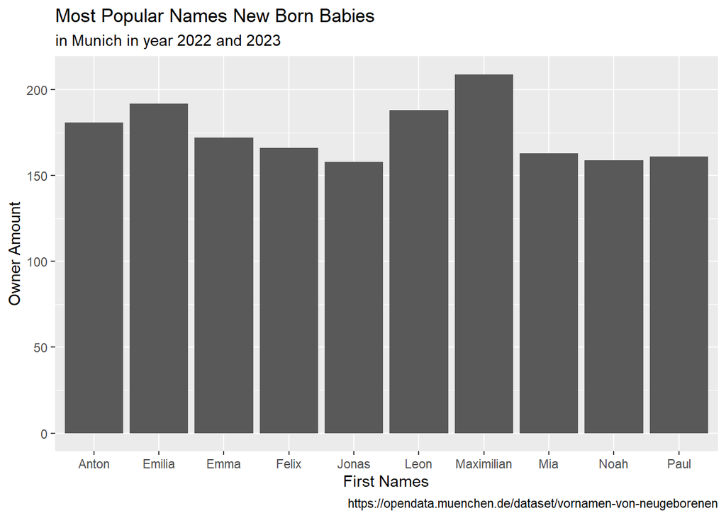

```r
vornamen_combined_3f <- vornamen_combined_3e %>%
  select(vorname, anzahl) %>%
  na.omit()

vornamen_combined_3f <-
  aggregate(vornamen_combined_3f$anzahl,
            list(vornamen_combined_3f$vorname),
            FUN = sum) %>%
  rename(anzahl = x, vorname = Group.1) %>%
  arrange(desc(anzahl)) %>%
  head(n = 10)

ggplot(vornamen_combined_3f) +
  aes(
    x = vorname,
    y = anzahl
  ) +
  geom_col() +
  labs(
    x = "First Names",
    y = "Owner Amount",
    title = "Most Popular Names New Born Babies",
    subtitle = "in Munich in year 2022 and 2023",
    caption = "https://opendata.muenchen.de/dataset/vornamen-von-neugeborenen"
  )
```

# Exercise 4

## 4c)

Dataset Name: 20th century deaths in US - CDC.csv Link: https://github.com/owid/owid-datasets/blob/master/datasets/20th%20century%20deaths%20in%20US%20-%20CDC/20th%20century%20deaths%20in%20US%20-%20CDC.csv

```r
deaths_20th <- read.csv("data/20th century deaths in US - CDC.csv")
```

## 4d)

Question:

This data set is compiled based on the list of top 10 causes of death. Did the deaths in US increase during the World War II? Even if the war did not affect US on a large scale. Calculate the average number of deaths during World War II and non-World War II years.

Tip: Use variable “Total.deaths….Deaths”.

Whether the World War II had influences to the deaths in a less negative affected country, which makes me curious.

## 4e)

The average number of deaths in US during WW2 was 1408657, and not during WW2 was 1501690 in 20th century. The average deaths during WW2 years were less than non WW2. One possibility is, the medical resources, which were sold to the war zone, were produced in large quantity, and the deaths in US were decrease.

```r
deaths_20th_4e_war <- deaths_20th %>%
  filter(Year >= 1939 & Year <= 1945)
deaths_20th_4e_nonWar <- deaths_20th %>%
  filter(Year < 1939 | Year > 1945)
mean(deaths_20th_4e_war$Total.deaths....Deaths)
```

```
## [1] 1408657
```

```r
mean(deaths_20th_4e_nonWar$Total.deaths....Deaths)
```

```
## [1] 1501690
```

## 4f)

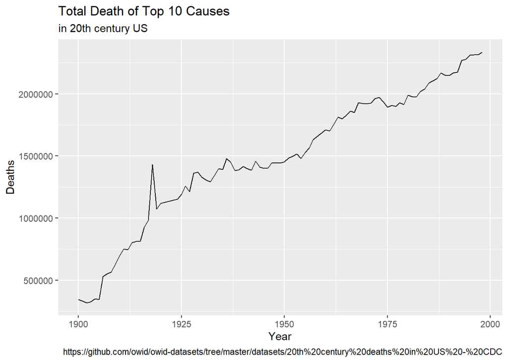

```r
ggplot(deaths_20th) +
  aes(
    x = Year,
    y = Total.deaths....Deaths
  ) +
  geom_line() +
  labs(
    x = "Year",
    y = "Deaths",
    title = "Total Death of Top 10 Causes",
    subtitle = "in 20th century US",
    caption = "https://github.com/owid/owid-datasets/tree/master/datasets/20th%20century%20deaths%20in%20US%20-%20CDC"
  )
```